# BUEC 333 - RMarkdown formatting instructions

Chris Muris and Tim Schulz

July 10, 2016

# E4.1

To start, I load the data, using the [haven](https://github.com/hadley/haven/) package.

```r
library(haven)
growthdata = read_dta('Growth.dta')
```

## (a)

To plot the relationship between tradeshare and growth, I use the [ggplot](http://ggplot2.org/) package.

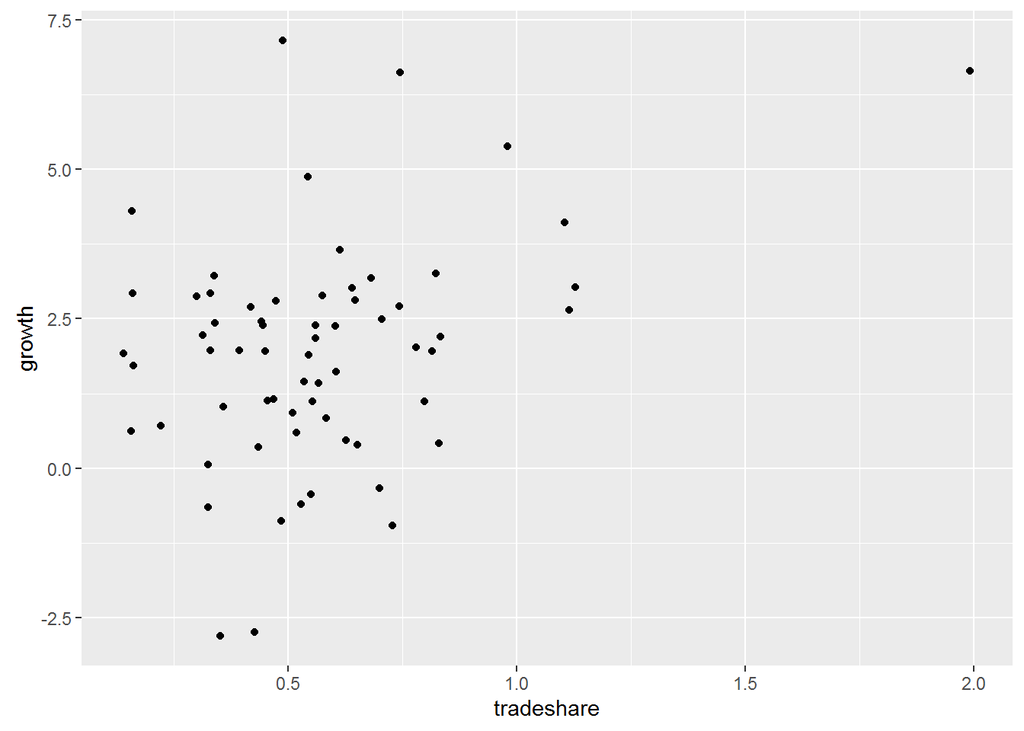

```r
require(ggplot2)
plot = ggplot(growthdata, aes(x=tradeshare, y=growth)) + geom_point()
plot
```

There appears to be a positive correlation between a country’s trade share and its growth rate.

## (b)

Next, I Mark Malta’s point in red, using the “colour” attribute in ggplot2, using code that I adapted from cookbook-r.

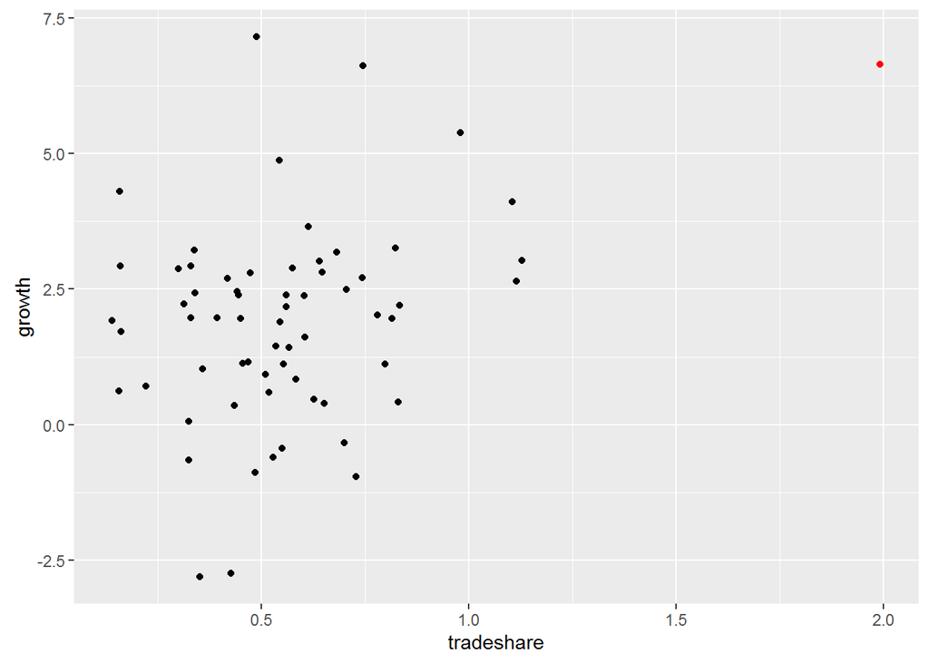

```r
plot + geom_point(aes(x=tradeshare, y=growth), growthdata[growthdata$country_name=='Malta',], colour='red')
```

Malta does indeed appear to be an outlier.

## (c)

Regress `growth` on `tradeshare`, using “lm”.

```r
reg1 = lm(growth ~ tradeshare, growthdata)
```

The estimated intercept and slope coefficients are

```r
reg1$coefficients
```

```
## (Intercept)  tradeshare
##   0.6402653   2.3064337
```

For a country with `tradeshare=0.5`, we predict a growth rate of

```r
as.numeric(predict(reg1, data.frame(tradeshare=.5)))
```

```
## [1] 1.793482
```

For a country with `tradeshare=1`, we predict a growth rate of

```r
as.numeric(predict(reg1, data.frame(tradeshare=1)))
```

```
## [1] 2.946699
```

These predictions differ by 0.5 times the estimated regression coefficient on tradeshare.

## (d)

Next, we run the same regression, but now excluding Malta. In what follows, I am using code that was demonstrated during the computer lab of July 8, 2016.

```r
reg2 = lm(growth ~ tradeshare, growthdata[growthdata$country_name!='Malta',])
```

Without Malta, the estimated intercept and slope coefficients are

```r
reg2$coefficients
```

```
## (Intercept)  tradeshare
##   0.9574107   1.6809047
```

Without Malta, for a country with `tradeshare=0.5`, we predict a growth rate of

```r
as.numeric(predict(reg2, data.frame(tradeshare=.5)))
```

```
## [1] 1.797863
```

This prediction is close to the one we obtained when using the data frame with Malta.

Without Malta, for a country with `tradeshare=1`, we predict a lower growth rate of

```r
as.numeric(predict(reg2, data.frame(tradeshare=1)))
```

```
## [1] 2.638315
```

This prediction is roughly 0.3 below the one we obtained using Malta.